# Coffee Spot Price Model

Jacob Norman

2/19/2019

## Exploratory Data Analysis

```
## 'data.frame':    642 obs. of  10 variables:
##  $ Year                     : int  1965 1965 1965 1965 1965 1965 1965 1965 1965 1965 ...
##  $ Month                    : Factor w/ 12 levels "April","August",..: 5 4 8 1 9 7 6 2 12 11 ...
##  $ Composite_indicator_price: num  NA NA 38.2 38.4 37 ...
##  $ Colombian_milds          : num  NA NA 46.8 47.2 46.8 ...
##  $ arabica                  : num  NA NA 44.1 44.2 43.6 ...
##  $ Brazilian_naturals       : num  NA NA 45 44.7 43.9 ...
##  $ Robustas                 : num  NA NA 24.1 24.8 22.1 ...
##  $ Total_production         : num  6740 6740 6740 6740 6740 ...
##  $ Arabica_production       : num  5425 5425 5425 5425 5425 ...
##  $ date                     : Date, format: "1965-01-01" "1965-02-01" ...
```

Below is the data provided by the *International Coffee Organisation* (ICO). The price of interest is the **arabica** column. This is the category “Other Milds”, which is the par delivery value of the futures contract.

| Year | Month | Composite_indicator_price | Colombian_milds | arabica | Brazilian_naturals | Robustas | Total_production | Arabica_production | date |
| --- | --- | --- | --- | --- | --- | --- | --- | --- | --- |
| 1965 | January | NA | NA | NA | NA | NA | 6740.372 | 5424.955 | 1965-01-01 |
| 1965 | February | NA | NA | NA | NA | NA | 6740.372 | 5424.955 | 1965-02-01 |
| 1965 | March | 38.20 | 46.75 | 44.11 | 45.03 | 24.13 | 6740.372 | 5424.955 | 1965-03-01 |
| 1965 | April | 38.41 | 47.17 | 44.25 | 44.71 | 24.81 | 6740.372 | 5424.955 | 1965-04-01 |
| 1965 | May | 37.05 | 46.78 | 43.56 | 43.88 | 22.12 | 6740.372 | 5424.955 | 1965-05-01 |
| 1965 | June | 39.27 | 47.32 | 44.46 | 44.10 | 27.81 | 6740.372 | 5424.955 | 1965-06-01 |
| 1965 | July | 40.67 | 47.34 | 44.52 | 43.58 | 32.55 | 6740.372 | 5424.955 | 1965-07-01 |
| 1965 | August | 42.20 | 48.32 | 45.39 | 43.67 | 36.65 | 6740.372 | 5424.955 | 1965-08-01 |
| 1965 | September | 41.65 | 48.85 | 45.29 | 42.59 | 35.45 | 6740.372 | 5424.955 | 1965-09-01 |
| 1965 | October | 42.15 | 48.29 | 45.85 | 42.75 | 36.67 | 6740.372 | 5424.955 | 1965-10-01 |
| 1965 | November | 41.73 | 49.76 | 46.54 | 42.66 | 34.44 | 6740.372 | 5424.955 | 1965-11-01 |
| 1965 | December | 42.32 | 49.38 | 46.80 | 42.85 | 36.07 | 6740.372 | 5424.955 | 1965-12-01 |
| 1966 | January | 42.15 | 49.03 | 45.93 | 42.60 | 36.38 | 4946.105 | 3747.153 | 1966-01-01 |
| 1966 | February | 40.91 | 49.60 | 44.13 | 41.48 | 34.40 | 4946.105 | 3747.153 | 1966-02-01 |
| 1966 | March | 40.14 | 48.74 | 43.27 | 40.66 | 33.79 | 4946.105 | 3747.153 | 1966-03-01 |
| 1966 | April | 40.30 | 48.41 | 43.27 | 40.55 | 34.56 | 4946.105 | 3747.153 | 1966-04-01 |
| 1966 | May | 40.46 | 48.82 | 42.92 | 40.82 | 34.76 | 4946.105 | 3747.153 | 1966-05-01 |
| 1966 | June | 39.83 | 48.35 | 41.87 | 40.75 | 33.65 | 4946.105 | 3747.153 | 1966-06-01 |
| 1966 | July | 39.49 | 48.00 | 41.59 | 40.59 | 33.10 | 4946.105 | 3747.153 | 1966-07-01 |
| 1966 | August | 39.14 | 47.32 | 41.62 | 40.32 | 32.61 | 4946.105 | 3747.153 | 1966-08-01 |
| 1966 | September | 38.31 | 45.54 | 40.78 | 40.04 | 31.72 | 4946.105 | 3747.153 | 1966-09-01 |
| 1966 | October | 38.45 | 45.49 | 40.27 | 39.99 | 32.42 | 4946.105 | 3747.153 | 1966-10-01 |
| 1966 | November | 38.24 | 44.94 | 40.24 | 39.45 | 32.62 | 4946.105 | 3747.153 | 1966-11-01 |
| 1966 | December | 37.91 | 43.96 | 39.59 | 39.50 | 32.36 | 4946.105 | 3747.153 | 1966-12-01 |
| 1967 | January | 37.22 | 43.22 | 38.56 | 38.75 | 31.96 | 5861.839 | 4291.618 | 1967-01-01 |
| 1967 | February | 37.13 | 42.36 | 38.29 | 38.01 | 33.05 | 5861.839 | 4291.618 | 1967-02-01 |
| 1967 | March | 36.68 | 40.89 | 37.37 | 38.00 | 32.87 | 5861.839 | 4291.618 | 1967-03-01 |
| 1967 | April | 37.43 | 41.37 | 38.59 | 38.43 | 33.90 | 5861.839 | 4291.618 | 1967-04-01 |
| 1967 | May | 38.30 | 42.11 | 40.33 | 38.75 | 34.96 | 5861.839 | 4291.618 | 1967-05-01 |
| 1967 | June | 38.57 | 42.42 | 41.24 | 38.41 | 35.51 | 5861.839 | 4291.618 | 1967-06-01 |

[output cut: 612 more lines]

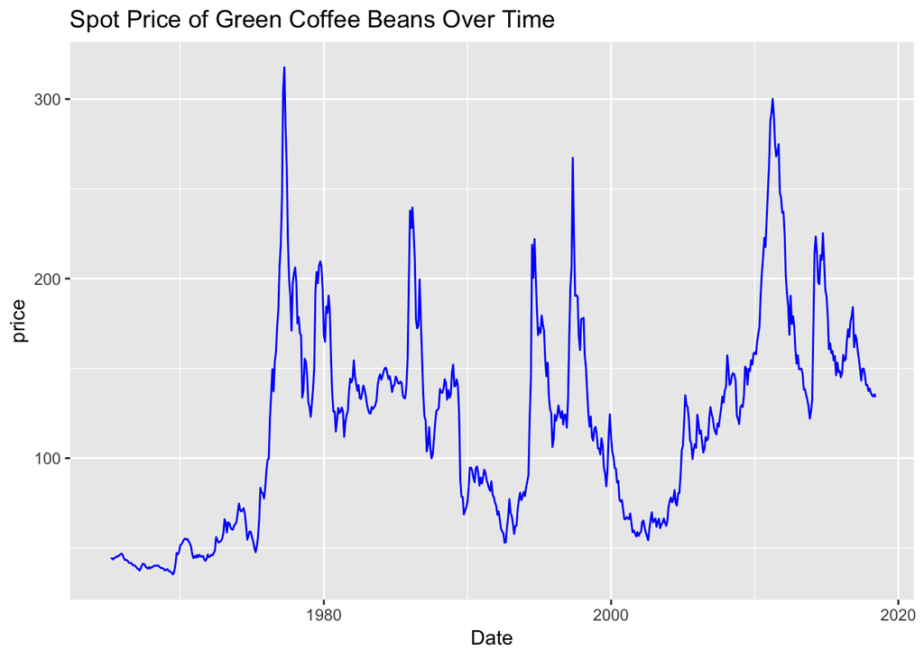

Here is an overview of the spot price over time, 1965 to 2018.

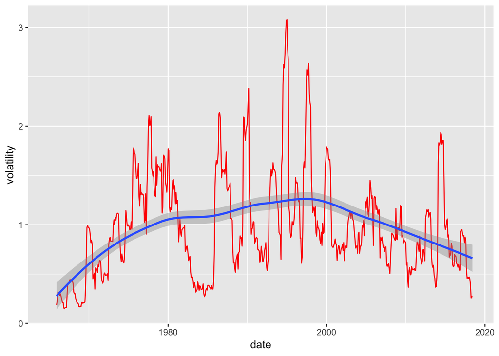

The variance of arabica beans is not consistent over time. A GARCH model might be required.

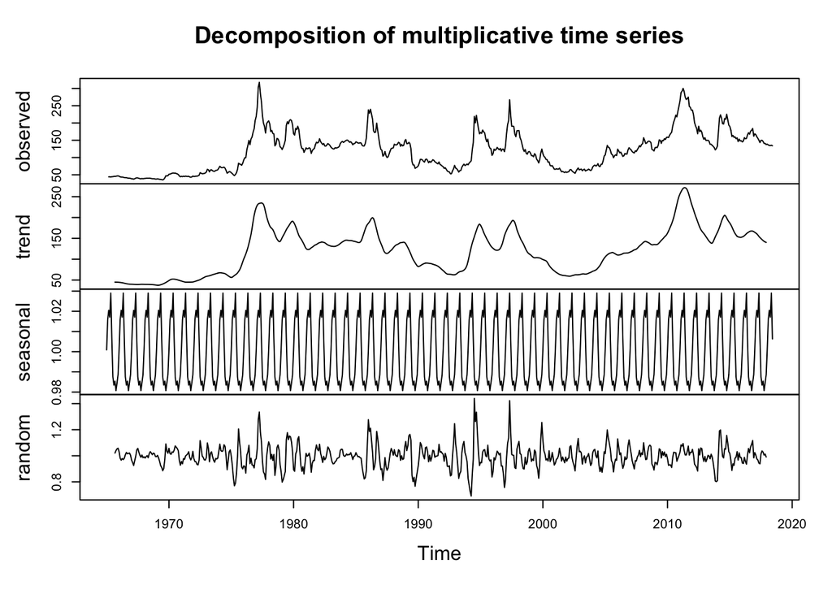

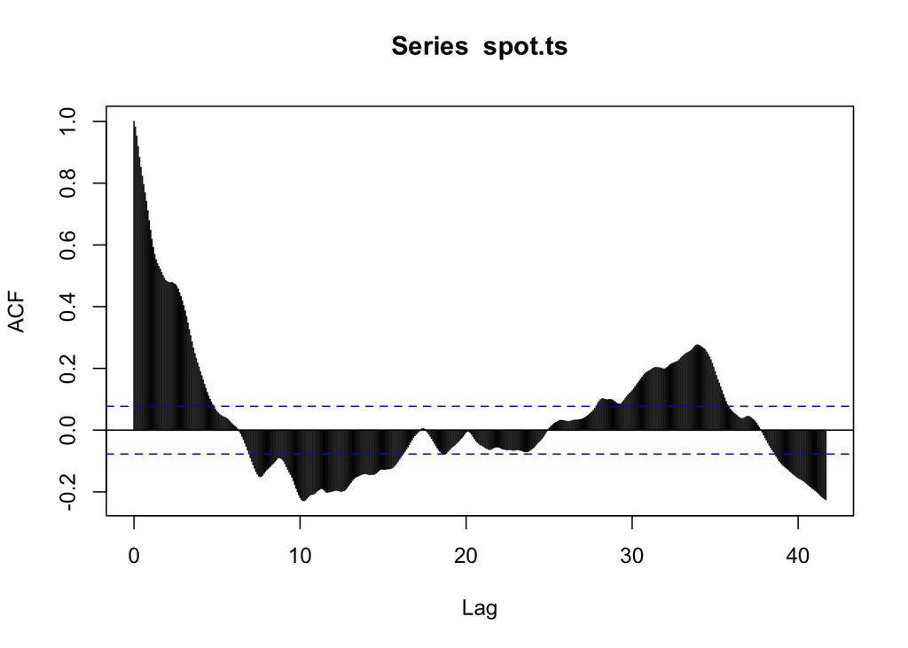

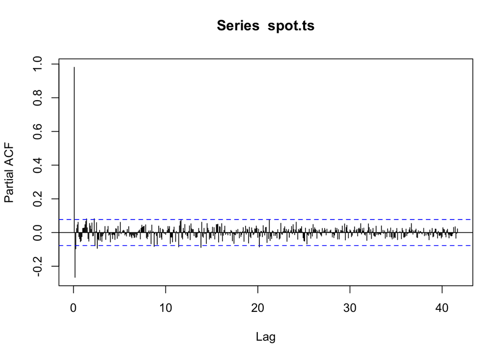

The ACF and PACF are very similar to the ones provided by the futures price.

## ARIMA Model

Once again we are going to create an ARIMA model based on R’s `auto.arima()` function. It believes an **ARIMA(2,1,2)** is the best model for the spot data. We later applied this function to the futures ARIMA-GARCH parameters.

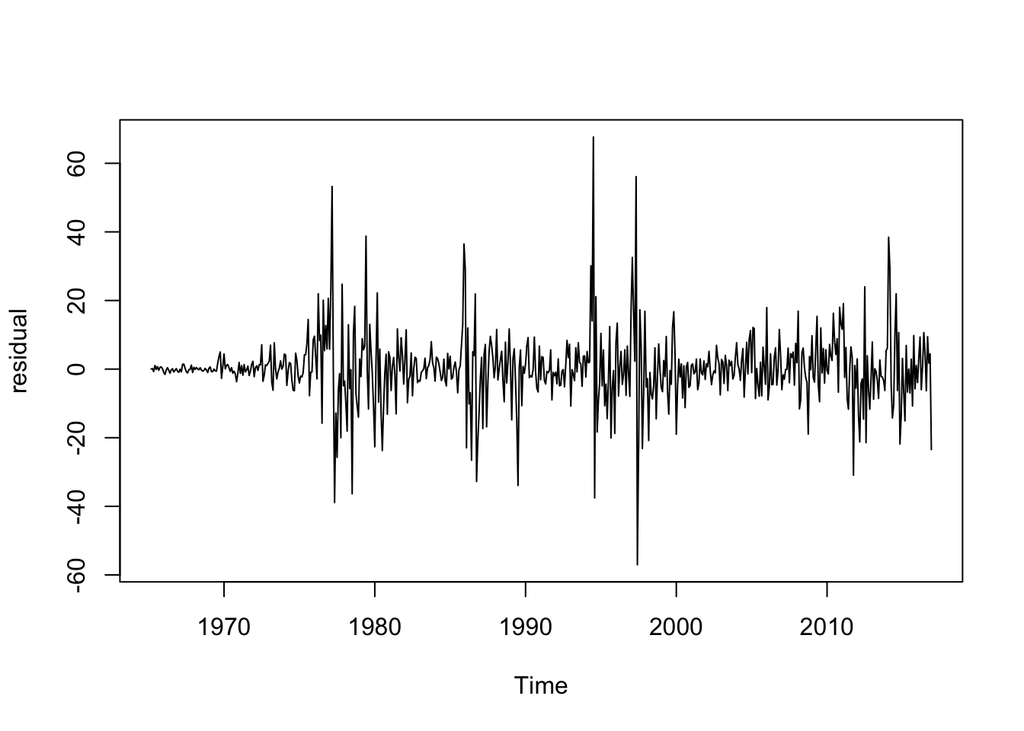

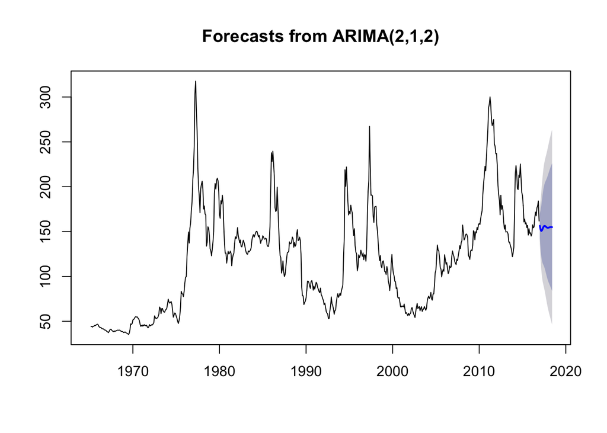

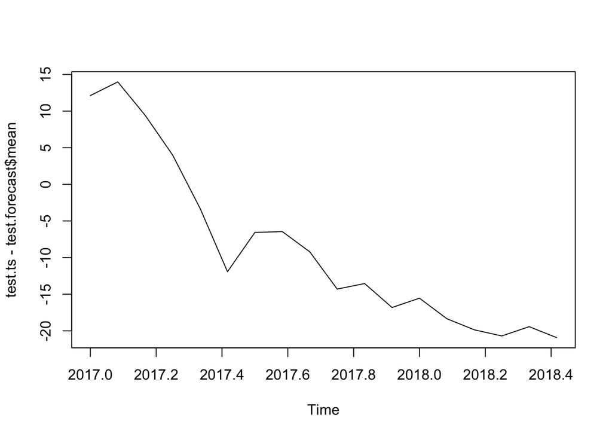

```
## Mean residual deviation: -8.7427
```

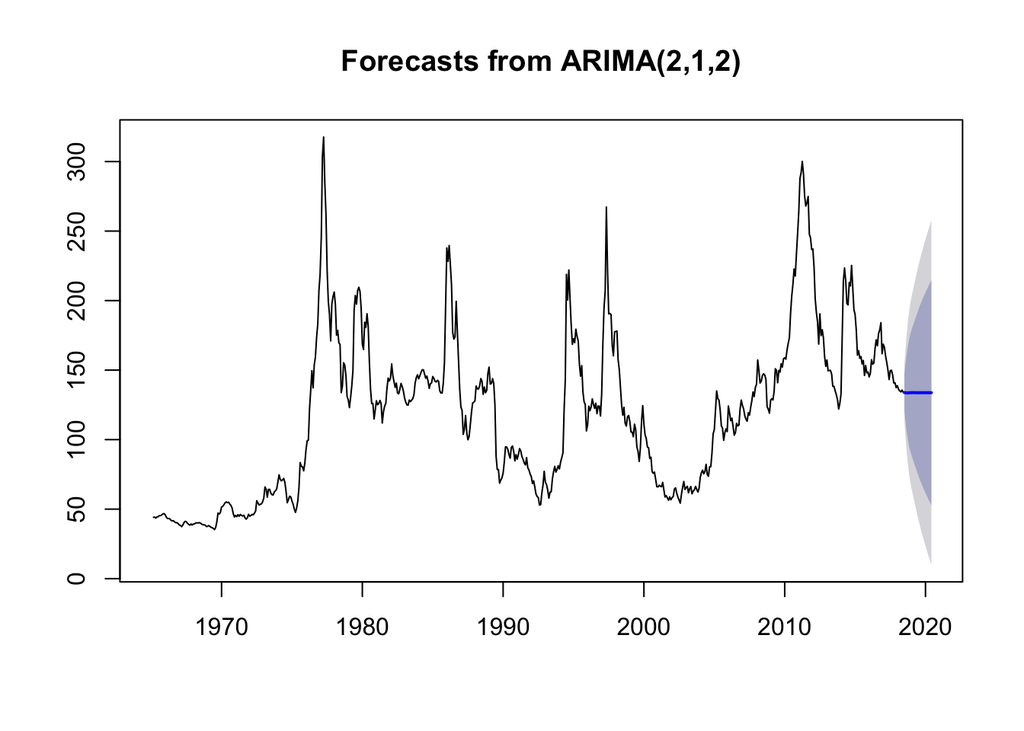

Like with the futures price analysis, we see that a simple ARIMA model tends to be very flat. This provides almost no value as a predictive tool. Let’s move on to an ARIMA-GARCH combination model.

## GARCH

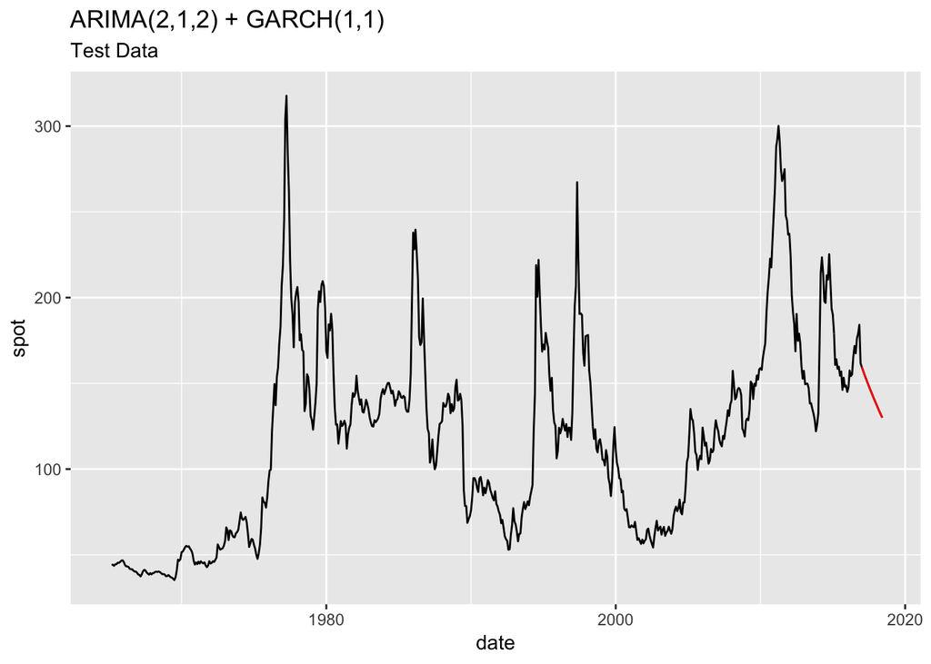

The red line indicates the projected price of in the spot market for arabica beans. It is no longer flat as it once was. Since this is for our training data set, we can test it on the 18 months of data we did not feed the model.

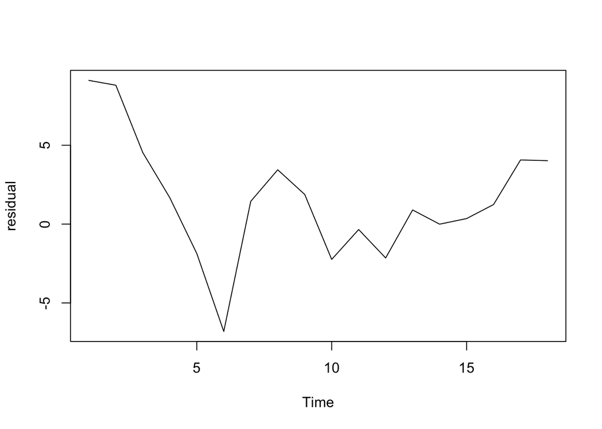

```
## Mean residual deviation: 1.5586
```

The residual analysis here is good. The mean residual deviation is close to zero, which is desired.

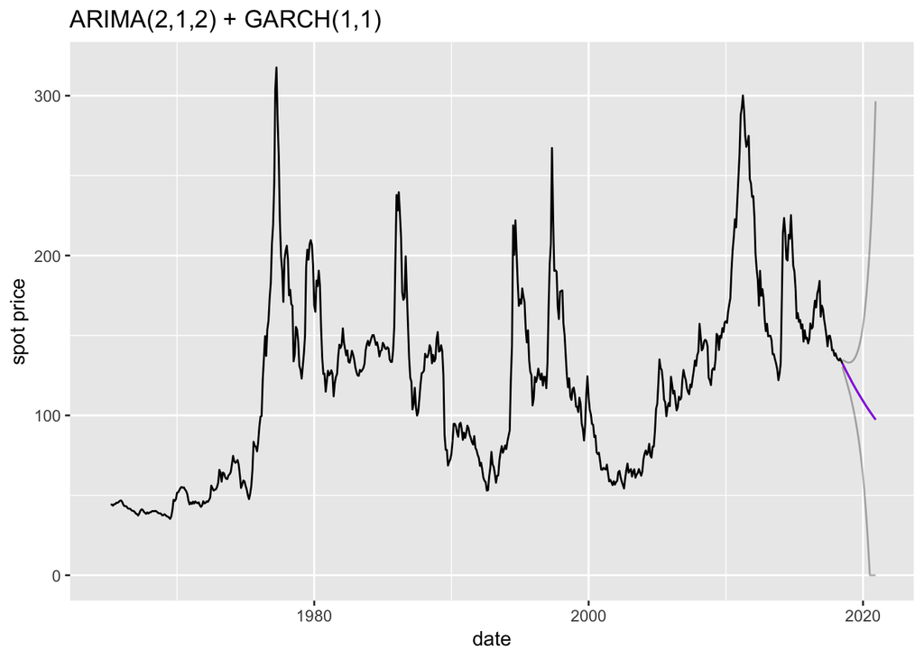

The model predicts that prices in the spot market will heavily decline through 2020. This is consistent with the prediction in the futures market, and since they are very highly correlated with one another, this makes logical sense.

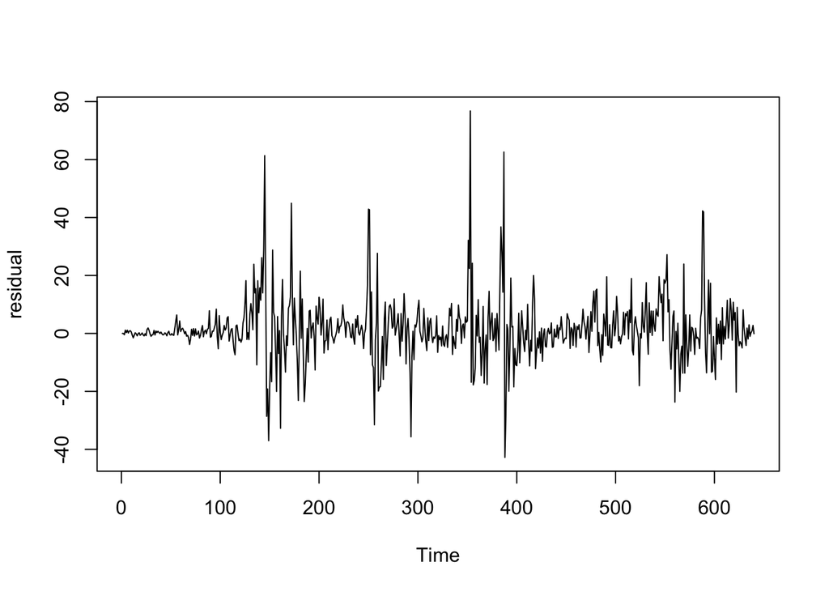

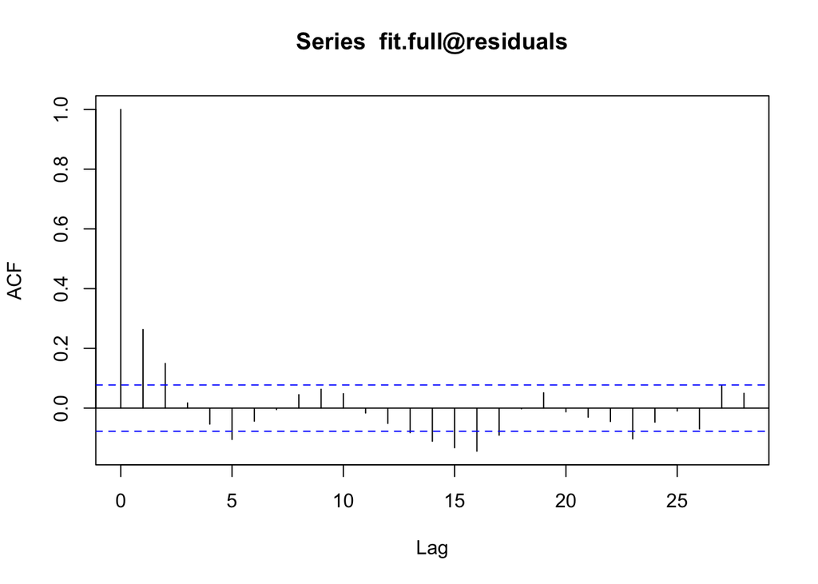

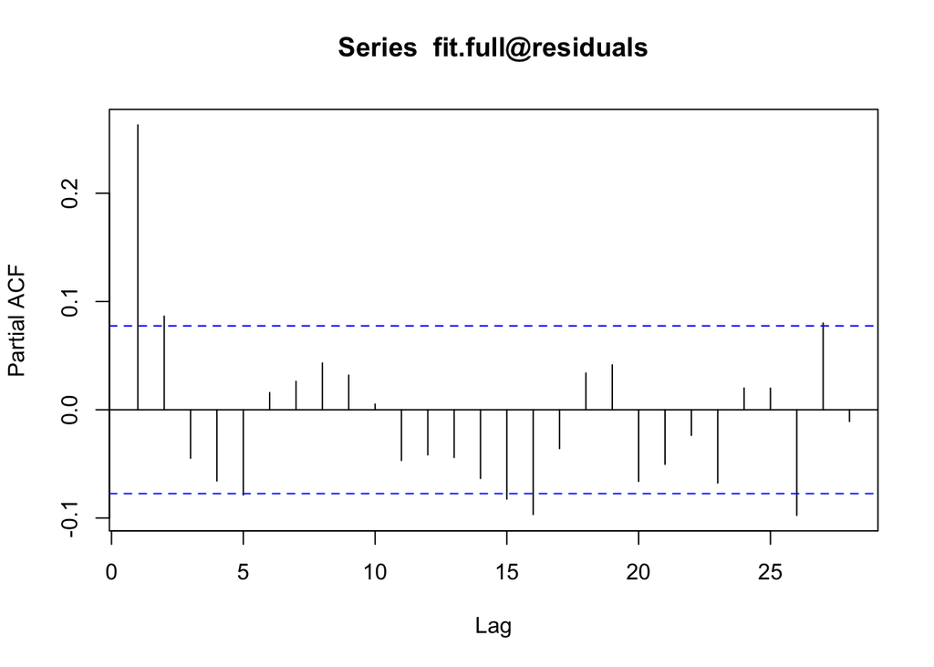

|  | date | price |
| --- | --- | --- |
| 643 | 2018-07-01 | 132.53945 |
| 644 | 2018-08-01 | 131.07073 |
| 645 | 2018-09-01 | 129.62260 |
| 646 | 2018-10-01 | 128.19476 |
| 647 | 2018-11-01 | 126.78693 |
| 648 | 2018-12-01 | 125.39882 |
| 649 | 2019-01-01 | 124.03017 |
| 650 | 2019-02-01 | 122.68070 |
| 651 | 2019-03-01 | 121.35013 |
| 652 | 2019-04-01 | 120.03821 |
| 653 | 2019-05-01 | 118.74467 |
| 654 | 2019-06-01 | 117.46925 |
| 655 | 2019-07-01 | 116.21171 |
| 656 | 2019-08-01 | 114.97179 |
| 657 | 2019-09-01 | 113.74924 |
| 658 | 2019-10-01 | 112.54382 |
| 659 | 2019-11-01 | 111.35529 |
| 660 | 2019-12-01 | 110.18342 |
| 661 | 2020-01-01 | 109.02797 |
| 662 | 2020-02-01 | 107.88870 |
| 663 | 2020-03-01 | 106.76540 |
| 664 | 2020-04-01 | 105.65784 |
| 665 | 2020-05-01 | 104.56580 |
| 666 | 2020-06-01 | 103.48907 |
| 667 | 2020-07-01 | 102.42742 |
| 668 | 2020-08-01 | 101.38064 |
| 669 | 2020-09-01 | 100.34853 |
| 670 | 2020-10-01 | 99.33089 |
| 671 | 2020-11-01 | 98.32750 |
| 672 | 2020-12-01 | 97.33818 |